# A Fiscal Health Index for Nonprofits, Tax Year 2023

Reproducible workflow and decision log

## Purpose

This document builds a fiscal health index for U.S. nonprofits from 2023 IRS Form 990 e-file data. It records every analytic decision made along the way and explains why it was made. It follows the strategy in `dev/health-index/index-construction.rmd`:

1. **Clustered indicators** that move together define a small number of empirical *dimensions*.
2. **Standalone indicators** are kept as individual measures rather than forced into a dimension.
3. **Noisy or redundant indicators** are dropped from the measurement system.

The staged `fiscal` pipeline implements this strategy. Each stage returns an object you can inspect:

```
fiscal_diagnostics() -> fiscal_triage() -> fiscal_dimensions()
   -> fiscal_health_fit() -> fiscal_health_score() -> fiscal_weights() -> fiscal_health_index()
```

The software discovers structure, but people decide what to keep, which way each indicator points, and what the dimensions mean. Every one of those decisions is marked below as a **Decision** block with its reasoning. Summary of decisions at the end collects them in one table.

**Key ideas**

- **Dimension:** a group of indicators that move together closely enough to be read as one underlying financial construct and scored as a single index.
- **Standalone indicator:** a ratio that is kept in the measurement system but not forced into a dimension, because it shares little variance with the rest.
- **Orientation:** the direction (“higher is healthier” or “lower is healthier”) applied to each indicator before indicators are averaged.
- **Rank-normal score:** each value’s rank mapped onto a standard normal distribution. It keeps ordering and ignores outliers.
- **Parallel analysis:** keep only the components whose eigenvalues beat those from random data of the same size.
- **Congruence:** a similarity score between two loading matrices. At 0.95 or above, the dimensions are effectively the same.

```r
library(dplyr)
library(knitr)
library(psych)

# Use the development version of fiscal in this repository when rendering
# from dev/health-index/; otherwise fall back to the installed package.
if (file.exists(file.path(params$pkg_dir, "DESCRIPTION"))) {
  pkgload::load_all(params$pkg_dir, quiet = TRUE)
} else {
  library(fiscal)
}
set.seed(params$seed)

# Small helpers used throughout.
num  <- function(x) suppressWarnings(as.numeric(x))
zero <- function(x) { x <- num(x); x[is.na(x)] <- 0; x }
pct  <- function(x, d = 1) paste0(format(round(100 * x, d), nsmall = d), "%")
fmt  <- function(x, d = 2) format(round(x, d), nsmall = d, big.mark = ",")
quiet <- function(expr) {
  out <- NULL
  invisible(capture.output(out <- suppressMessages(suppressWarnings(expr))))
  out
}
```

## 1. Data

### 1.1 Retrieve and deduplicate 2023 e-filings

We pull the one-to-one Form 990 tables (header, Part I summary, Part VIII revenue, Part IX expenses, Part X balance sheet) with `retrieve_efile_data()`. Then `deduplicate()` keeps one filing per EIN: it drops group and partial-year returns and keeps the most recent submission. Downloads are about 1.4 GB, so the merged, deduplicated file is cached under `params$data_dir`.

```r
dir.create(params$data_dir, recursive = TRUE, showWarnings = FALSE)
cache_file <- file.path(params$data_dir, "efile-2023.rds")
# data-raw/create-dat10k.R caches an equivalent deduplicated extract; reuse it
# rather than downloading the tables again.
shared_cache <- file.path(params$data_dir, "efile-2023-bmf-dedup.rds")
if (!file.exists(cache_file) && file.exists(shared_cache)) cache_file <- shared_cache

if (file.exists(cache_file)) {
  efile <- readRDS(cache_file)
} else {
  efile <- retrieve_efile_data(year = 2023, include_bmf = FALSE,
                               path = file.path(params$data_dir, "efdata"),
                               verbose = FALSE)
  efile <- deduplicate(efile, verbose = FALSE)
  saveRDS(efile, cache_file)
}

table(efile$RETURN_TYPE)
```

```
##
##    990  990EZ
## 325057 196777
```

### 1.2 Analysis sample

```r
n_all <- nrow(efile)
d <- efile[efile$RETURN_TYPE == "990", ]
n_990 <- nrow(d)
d <- d[which(num(d$F9_09_EXP_TOT_TOT) > 0 &
             num(d$F9_10_ASSET_TOT_EOY) > 0 &
             num(d$F9_08_REV_TOT_TOT) > 0), ]
d <- sanitize_financials(d)
rm(efile); invisible(gc())

data.frame(step = c("Deduplicated 2023 filings", "Full Form 990 filers",
                    "Positive revenue, expenses, and assets"),
           n = format(c(n_all, n_990, nrow(d)), big.mark = ","))
```

| step | n |
| --- | --- |
| Deduplicated 2023 filings | 521,834 |
| Full Form 990 filers | 325,057 |
| Positive revenue, expenses, and assets | 314,548 |

> **Decision 1: Restrict the sample to full Form 990 filers with positive revenue, expenses, and total assets.**

> *Why:* Most fiscal health ratios need line items that only appear on the full Form 990: Part IX functional expenses, and Part X detail on cash, payables, fixed assets, and net-asset classes. 990-EZ filers would enter with structural zeros that look like real values. Mixing them in would mostly separate *form type* rather than financial condition. Positive denominators keep the core ratios (margins, return on assets, months of spending) defined for every organization. As a result, the index describes organizations large enough to file the full 990 (roughly $200k+ in gross receipts or $500k+ in assets). It does not describe the smallest nonprofits.

## 2. Correcting indicator inputs

Before choosing indicators, we checked whether each candidate ratio measures what it claims to. Three problems turned up, and each changes what goes into the model.

### 2.1 Net-asset classes for filers that do not follow SFAS 117

Part X lines 27–28 (net assets without/with donor restrictions) apply only to organizations that follow SFAS 117 / ASC 958. Other filers report equity on lines 30–32 (capital stock, paid-in surplus, retained earnings). For those filers, unrestricted net assets read as **zero** even when total net assets are large. Every reserve metric built on unrestricted net assets then understates their reserves.

```r
unr <- zero(d$F9_10_NAFB_UNRESTRICT_EOY)
res <- zero(d$F9_10_NAFB_RESTRICT_EOY)
tot <- zero(d$F9_10_NAFB_TOT_EOY)
non_sfas <- unr == 0 & res == 0 & tot != 0
d$NAFB_UNRESTRICT_ADJ <- ifelse(unr == 0 & res == 0, tot, unr)

data.frame(
  measure = c("Report no net-asset classes but nonzero total net assets",
              "Negative total net assets"),
  share = pct(c(mean(non_sfas), mean(tot < 0)))
)
```

| measure | share |
| --- | --- |
| Report no net-asset classes but nonzero total net assets | 25.1% |
| Negative total net assets | 4.9% |

> **Decision 2: When lines 27–28 are both zero, treat total net assets as unrestricted.**

> *Why:* About 25% of the sample would otherwise score as having no discretionary reserves. Without donor-restriction reporting, an organization’s equity is, for practical purposes, unrestricted: retained earnings and paid-in capital are not donor-restricted. The adjusted field feeds the operating-reserve and liquid-assets metrics through their column arguments. The package functions themselves are unchanged.

### 2.2 Two ratio functions that do not match their documentation

```r
d$CASH_SAVINGS   <- zero(d$F9_10_ASSET_CASH_EOY) + zero(d$F9_10_ASSET_SAVING_EOY)
d$EXP_MGMT_FUNDR <- zero(d$F9_09_EXP_TOT_MGMT) + zero(d$F9_09_EXP_TOT_FUNDR)

pkg <- quiet(compute_all(d, metrics = c("ratio", "z"), append_to_df = FALSE))

overhead_fixed <- d$EXP_MGMT_FUNDR / num(d$F9_09_EXP_TOT_TOT)
prog_exp_raw   <- pkg$prog_exp

data.frame(
  check = c("Package overhead identical to administrative-expense ratio",
            "Filers with any fundraising expense",
            "Corrected overhead vs. program-expense ratio (Pearson r)",
            "Package cash/assets vs. (cash + savings)/assets (Spearman rho)"),
  value = c(isTRUE(all.equal(pkg$overhead, pkg$expenses_admin)),
            pct(mean(zero(d$F9_09_EXP_TOT_FUNDR) > 0)),
            fmt(cor(overhead_fixed, prog_exp_raw, use = "pair"), 3),
            fmt(cor(pkg$cash_assets, d$CASH_SAVINGS / num(d$F9_10_ASSET_TOT_EOY),
                    method = "spearman", use = "pair"), 3))
)
```

| check | value |
| --- | --- |
| Package overhead identical to administrative-expense ratio | TRUE |
| Filers with any fundraising expense | 32.5% |
| Corrected overhead vs. program-expense ratio (Pearson r) | -0.924 |
| Package cash/assets vs. (cash + savings)/assets (Spearman rho) | 0.720 |

- `get_overhead_ratio()` leaves fundraising out of its numerator. The result is identical to `get_expenses_admin_ratio()`, even though many filers report fundraising costs. Once corrected, overhead is by construction the complement of the program-expense ratio (program + management + fundraising = total). The observed r of -0.92 falls short of −1 only because of reporting noise in the functional columns, so overhead adds no independent information.
- `get_cash_assets_ratio()` leaves savings and temporary cash investments out of its numerator. We pass `cash = "CASH_SAVINGS"` to get the documented definition.

> **Decision 3: Use corrected inputs for cash/assets, and exclude overhead as a complement of the program-expense ratio.** The underlying function fixes are tracked separately from this analysis.

### 2.3 Compute the corrected candidate metrics

```r
f <- d
f <- quiet(get_days_cash_operations(f, sanitize = FALSE))
f <- quiet(get_cash_assets_ratio(f, cash = "CASH_SAVINGS", sanitize = FALSE))
f <- quiet(get_operating_reserve_ratio(f, unrestricted_net_assets = "NAFB_UNRESTRICT_ADJ",
                                       sanitize = FALSE))
f <- quiet(get_liquid_assets_months(f, unrestricted_net_assets = "NAFB_UNRESTRICT_ADJ",
                                    sanitize = FALSE))
f <- quiet(get_debt_assets_ratio(f, sanitize = FALSE))
f <- quiet(get_surplus_margin_ratio(f, sanitize = FALSE))
f <- quiet(get_profit_margin_predepr(f, sanitize = FALSE))
f <- quiet(get_return_assets_ratio(f, sanitize = FALSE))
f <- quiet(get_program_expenses_ratio(f, sanitize = FALSE))
f <- quiet(get_expenses_admin_ratio(f, sanitize = FALSE))
f <- quiet(get_self_sufficiency_ratio(f, sanitize = FALSE))
f <- quiet(get_assets_revenue_ratio(f, sanitize = FALSE))
```

## 3. Candidate indicator pool

The package registry (`fiscal_metrics()`) lists 48 metrics. An index needs indicators that are **directional** (more is clearly better or clearly worse), **scale-free** (not a dollar amount), **defined for nearly everyone**, **monotone in health**, and **not algebraically identical** to another indicator. The table below screens every metric against those criteria.

```r
reg <- fiscal_metrics()
coverage <- vapply(reg$metric, function(m)
  if (m %in% names(pkg)) mean(is.finite(pkg[[m]])) else NA_real_, numeric(1))

reason <- setNames(rep(NA_character_, nrow(reg)), reg$metric)
reason[reg$direction == "context"] <-
  "Composition measure; registry direction is context-dependent"
reason["cash_on_hand"]   <- "Dollar level: measures size, not condition"
reason["cash_burn"]      <- "Dollars per month (not a ratio): measures size"
reason[c("current", "quick", "cash_liq")] <-
  "Undefined when current liabilities = 0 (structural missingness)"
reason[c("debt_equity", "debt_netassets", "debt_shortterm",
         "return_netassets", "netassets_growth")] <-
  "Net-asset denominator can be <= 0, so the ratio's sign flips (not monotone)"
reason[c("debt_secured", "debt_unsecured")] <-
  "Liability composition; undefined when total liabilities = 0"
reason["fundr_eff"]      <- "Undefined without contributions; registry direction is reversed"
reason["equity"]         <- "Identity: equity = 1 - debt_assets"
reason["months_cash_ops"] <- "Identity: days_cash_ops x 12/365"
reason["overhead"]       <- "Package bug (= admin ratio); corrected form = 1 - prog_exp"
reason["profit_postdepr"] <- "Duplicates surplus_margin (Part VIII/IX vs. Part I)"
reason["days_cash_inv"]  <- "Adds inventories (line 8), not investments; mis-specified"
reason["cash_assets"]    <- "Enters pool (numerator corrected)"
reason[c("op_reserve", "liquid_assets_months")] <- "Enters pool (adjusted unrestricted net assets)"
reason[is.na(reason)]    <- "Enters pool"

screen <- data.frame(metric = reg$metric, category = reg$category,
                     direction = reg$direction, coverage = pct(coverage, 0),
                     decision = reason, row.names = NULL)
pool <- screen$metric[grepl("^Enters pool", screen$decision)]
stopifnot(all(pool %in% names(f)))
kable(screen[order(!grepl("^Enters", screen$decision), screen$category), ],
      row.names = FALSE)
```

| metric | category | direction | coverage | decision |
| --- | --- | --- | --- | --- |
| op_reserve | asset_structure | higher | 100% | Enters pool (adjusted unrestricted net assets) |
| assets_rev | asset_structure | lower | 100% | Enters pool |
| prog_exp | expense_structure | higher | 100% | Enters pool |
| expenses_admin | expense_structure | lower | 100% | Enters pool |
| cash_assets | liquidity | higher | 100% | Enters pool (numerator corrected) |
| days_cash_ops | liquidity | higher | 100% | Enters pool |
| liquid_assets_months | liquidity | higher | 100% | Enters pool (adjusted unrestricted net assets) |
| surplus_margin | performance | higher | 100% | Enters pool |
| return_assets | performance | higher | 100% | Enters pool |
| profit_predepr | performance | higher | 100% | Enters pool |
| self_suff | performance | higher | 100% | Enters pool |
| debt_assets | solvency | lower | 100% | Enters pool |
| netassets_comp | asset_structure | context | 100% | Composition measure; registry direction is context-dependent |
| netassets_growth | asset_structure | higher | 98% | Net-asset denominator can be <= 0, so the ratio’s sign flips (not monotone) |
| investments_assets | asset_structure | context | 100% | Composition measure; registry direction is context-dependent |
| land_assets_net | asset_structure | context | 100% | Composition measure; registry direction is context-dependent |
| land_assets_gross | asset_structure | context | 100% | Composition measure; registry direction is context-dependent |
| overhead | expense_structure | lower | 100% | Package bug (= admin ratio); corrected form = 1 - prog_exp |
| fundr_eff | expense_structure | higher | 82% | Undefined without contributions; registry direction is reversed |
| expenses_compensation | expense_structure | context | 100% | Composition measure; registry direction is context-dependent |
| expenses_grants | expense_structure | context | 100% | Composition measure; registry direction is context-dependent |
| expenses_membbenefits | expense_structure | context | 100% | Composition measure; registry direction is context-dependent |
| expenses_feesforservice | expense_structure | context | 100% | Composition measure; registry direction is context-dependent |
| expenses_affiliates | expense_structure | context | 100% | Composition measure; registry direction is context-dependent |
| current | liquidity | higher | 59% | Undefined when current liabilities = 0 (structural missingness) |
| quick | liquidity | higher | 59% | Undefined when current liabilities = 0 (structural missingness) |
| cash_liq | liquidity | higher | 59% | Undefined when current liabilities = 0 (structural missingness) |
| cash_on_hand | liquidity | higher | 100% | Dollar level: measures size, not condition |
| cash_burn | liquidity | higher | 100% | Dollars per month (not a ratio): measures size |
| days_cash_inv | liquidity | higher | 100% | Adds inventories (line 8), not investments; mis-specified |
| months_cash_ops | liquidity | higher | 100% | Identity: days_cash_ops x 12/365 |
| return_netassets | performance | higher | 98% | Net-asset denominator can be <= 0, so the ratio’s sign flips (not monotone) |
| profit_postdepr | performance | higher | 100% | Duplicates surplus_margin (Part VIII/IX vs. Part I) |
| grants_govt | revenue_structure | context | 100% | Composition measure; registry direction is context-dependent |
| donations_rev | revenue_structure | context | 100% | Composition measure; registry direction is context-dependent |
| earned_income | revenue_structure | context | 100% | Composition measure; registry direction is context-dependent |
| revenue_programs | revenue_structure | context | 100% | Composition measure; registry direction is context-dependent |
| revenue_fedcampaign | revenue_structure | context | 100% | Composition measure; registry direction is context-dependent |
| revenue_membdues | revenue_structure | context | 100% | Composition measure; registry direction is context-dependent |
| revenue_fundevents | revenue_structure | context | 100% | Composition measure; registry direction is context-dependent |
| revenue_reltdorgs | revenue_structure | context | 100% | Composition measure; registry direction is context-dependent |
| invest_income | revenue_structure | context | 100% | Composition measure; registry direction is context-dependent |
| debt_equity | solvency | lower | 74% | Net-asset denominator can be <= 0, so the ratio’s sign flips (not monotone) |
| debt_netassets | solvency | lower | 74% | Net-asset denominator can be <= 0, so the ratio’s sign flips (not monotone) |
| debt_shortterm | solvency | lower | 100% | Net-asset denominator can be <= 0, so the ratio’s sign flips (not monotone) |
| debt_secured | solvency | lower | 73% | Liability composition; undefined when total liabilities = 0 |
| debt_unsecured | solvency | lower | 73% | Liability composition; undefined when total liabilities = 0 |
| equity | solvency | higher | 100% | Identity: equity = 1 - debt_assets |

Supporting evidence for the identity and structural-missingness screens:

```r
data.frame(
  check = c("Current liabilities (payables + grants payable) equal zero",
            "Total liabilities equal zero",
            "Spearman rho, surplus_margin vs. profit_postdepr",
            "Spearman rho, days_cash_ops vs. months_cash_ops",
            "Pearson r, equity vs. debt_assets"),
  value = c(pct(mean(zero(d$F9_10_LIAB_ACC_PAYABLE_EOY) +
                     zero(d$F9_10_LIAB_GRANT_PAYABLE_EOY) == 0)),
            pct(mean(zero(d$F9_10_LIAB_TOT_EOY) == 0)),
            fmt(cor(pkg$surplus_margin, pkg$profit_postdepr, method = "spearman", use = "pair"), 3),
            fmt(cor(pkg$days_cash_ops, pkg$months_cash_ops, method = "spearman", use = "pair"), 3),
            fmt(cor(pkg$equity, pkg$debt_assets, use = "pair"), 3))
)
```

| check | value |
| --- | --- |
| Current liabilities (payables + grants payable) equal zero | 40.9% |
| Total liabilities equal zero | 27.1% |
| Spearman rho, surplus_margin vs. profit_postdepr | 1.000 |
| Spearman rho, days_cash_ops vs. months_cash_ops | 1.000 |
| Pearson r, equity vs. debt_assets | -1.000 |

> **Decision 4: Screen out metrics that are directional in name only.** 12 indicators enter the model: `cash_assets`, `days_cash_ops`, `liquid_assets_months`, `debt_assets`, `surplus_margin`, `return_assets`, `profit_predepr`, `self_suff`, `prog_exp`, `expenses_admin`, `op_reserve`, `assets_rev`.

> *Why:*
> - **Composition measures** (revenue mix, expense mix, asset mix) describe a business model, not financial condition. A high government-grant share is neither healthy nor unhealthy on its face.
> - **Dollar levels** would make the index mostly about size.
> - **Structural missingness:** current ratios are undefined for the ~40% of filers with no payables. Estimating dimensions on complete cases would quietly drop the simplest balance sheets.
> - **Signed net-asset denominators** make ratios non-monotone. An insolvent organization with negative net assets gets a *negative* debt-to-net-assets ratio and would rank as the least leveraged.
> - **Algebraic identities** make the correlation matrix singular. That breaks KMO and factor estimation and inflates a construct’s apparent weight.

> Borderline cases (`self_suff`, `assets_rev`, `prog_exp`) are registry-directional but arguably context-dependent. They enter the pool so the data can show how they behave, and they are revisited at triage.

## 4. Transformation: rank-normal scores

Nonprofit ratios have extreme tails. Near-zero denominators and data-entry errors produce values in the thousands. The package’s `_z` columns winsorize and then apply a fitted normalizing transform. Correlation-based modeling, though, needs the Pearson correlations between transformed indicators to preserve the monotone association in the raw data. We checked whether they do.

```r
rank_normal <- function(x) {
  x[!is.finite(x)] <- NA
  r <- rank(x, na.last = "keep", ties.method = "average")
  qnorm((r - 0.5) / sum(!is.na(x)))
}

pairs <- list(c("prog_exp", "expenses_admin"), c("days_cash_ops", "debt_assets"),
              c("surplus_margin", "return_assets"), c("debt_shortterm", "debt_assets"),
              c("days_cash_ops", "surplus_margin"))
kable(do.call(rbind, lapply(pairs, function(p) {
  a <- pkg[[p[1]]]; b <- pkg[[p[2]]]
  a[!is.finite(a)] <- NA; b[!is.finite(b)] <- NA
  data.frame(pair = paste(p, collapse = " ~ "),
             spearman_raw   = cor(a, b, method = "spearman", use = "pair"),
             pearson_pkg_z  = cor(pkg[[paste0(p[1], "_z")]], pkg[[paste0(p[2], "_z")]], use = "pair"),
             pearson_rank_normal = cor(rank_normal(a), rank_normal(b), use = "pair"))
})), digits = 3)
```

| pair | spearman_raw | pearson_pkg_z | pearson_rank_normal |
| --- | --- | --- | --- |
| prog_exp ~ expenses_admin | -0.465 | -0.118 | -0.434 |
| days_cash_ops ~ debt_assets | -0.243 | -0.249 | -0.250 |
| surplus_margin ~ return_assets | 0.856 | 0.697 | 0.782 |
| debt_shortterm ~ debt_assets | 0.495 | 0.078 | 0.327 |
| days_cash_ops ~ surplus_margin | 0.390 | 0.393 | 0.382 |

```r
zc <- paste0(intersect(pool, names(pkg)), "_z")
kable(data.frame(column = zc,
                 mean = sapply(pkg[zc], mean, na.rm = TRUE),
                 sd   = sapply(pkg[zc], sd, na.rm = TRUE),
                 share_abs_gt_4 = sapply(pkg[zc], function(v) mean(abs(v) > 4, na.rm = TRUE))),
      digits = 3, row.names = FALSE)
```

| column | mean | sd | share_abs_gt_4 |
| --- | --- | --- | --- |
| cash_assets_z | 0.263 | 2.860 | 0.202 |
| days_cash_ops_z | 0.303 | 1.226 | 0.020 |
| liquid_assets_months_z | 0.027 | 1.246 | 0.020 |
| debt_assets_z | -0.033 | 0.895 | 0.000 |
| surplus_margin_z | 0.000 | 1.189 | 0.020 |
| return_assets_z | 0.009 | 1.205 | 0.022 |
| profit_predepr_z | 0.000 | 1.189 | 0.020 |
| self_suff_z | -0.713 | 0.978 | 0.000 |
| prog_exp_z | -0.310 | 6.135 | 0.263 |
| expenses_admin_z | -2.327 | 4.991 | 0.269 |
| op_reserve_z | 0.025 | 1.207 | 0.020 |
| assets_rev_z | 0.391 | 1.282 | 0.019 |

> **Decision 5: Model rank-normal (van der Waerden) scores of the raw ratios, not the package `_z` columns.**

> *Why:* For several pairs, the `_z` columns shrink strong raw associations toward zero (compare `spearman_raw` with `pearson_pkg_z`). Some `_z` columns are far from standardized (means well away from 0, heavy tails). Rank-normal scores are bounded, symmetric, and insensitive to outliers. Their Pearson correlations track the raw Spearman correlations, so the correlation matrix that PCA sees reflects the real monotone structure in the data.

> *Cost:* The transform depends on the reference distribution. To score a later year on the 2023 scale, map each value to its position in the 2023 distribution (for example with `ecdf()`) rather than re-ranking within the new year.

```r
ind <- as.data.frame(lapply(f[pool], rank_normal))
names(ind) <- pool
kable(data.frame(indicator = pool,
                 observed = pct(sapply(ind, function(v) mean(!is.na(v))))),
      row.names = FALSE)
```

| indicator | observed |
| --- | --- |
| cash_assets | 100.0% |
| days_cash_ops | 100.0% |
| liquid_assets_months | 100.0% |
| debt_assets | 100.0% |
| surplus_margin | 100.0% |
| return_assets | 100.0% |
| profit_predepr | 100.0% |
| self_suff | 100.0% |
| prog_exp | 100.0% |
| expenses_admin | 100.0% |
| op_reserve | 100.0% |
| assets_rev | 100.0% |

## 5. Stage 1: Diagnostics

```r
diagnostics <- fiscal_diagnostics(ind)
cat("Overall KMO (MSA):", fmt(diagnostics$kmo$MSA, 3), "\n")
```

```
## Overall KMO (MSA): 0.608
```

```r
kable(diagnostics$variables[, c("variable", "kmo_msa", "communality", "smc",
                                "mean_abs_cor", "max_abs_cor", "redundant_with")],
      digits = 3, row.names = FALSE)
```

| variable | kmo_msa | communality | smc | mean_abs_cor | max_abs_cor | redundant_with |
| --- | --- | --- | --- | --- | --- | --- |
| cash_assets | 0.256 | 0.619 | 0.744 | 0.147 | 0.481 |  |
| days_cash_ops | 0.541 | 0.443 | 0.771 | 0.309 | 0.573 |  |
| liquid_assets_months | 0.711 | 0.888 | 0.880 | 0.325 | 0.921 | op_reserve |
| debt_assets | 0.697 | 0.390 | 0.435 | 0.226 | 0.552 |  |
| surplus_margin | 0.654 | 0.978 | 0.934 | 0.284 | 0.948 | profit_predepr |
| return_assets | 0.921 | 0.632 | 0.629 | 0.241 | 0.782 |  |
| profit_predepr | 0.658 | 0.945 | 0.926 | 0.278 | 0.948 | surplus_margin |
| self_suff | 0.618 | 0.060 | 0.102 | 0.101 | 0.212 |  |
| prog_exp | 0.525 | 0.050 | 0.223 | 0.100 | 0.434 |  |
| expenses_admin | 0.499 | 0.036 | 0.220 | 0.087 | 0.434 |  |
| op_reserve | 0.655 | 0.851 | 0.880 | 0.321 | 0.921 | liquid_assets_months |
| assets_rev | 0.440 | 0.740 | 0.799 | 0.227 | 0.537 |  |

```r
kable(round(diagnostics$correlation, 2))
```

|  | cash_assets | days_cash_ops | liquid_assets_months | debt_assets | surplus_margin | return_assets | profit_predepr | self_suff | prog_exp | expenses_admin | op_reserve | assets_rev |
| --- | --- | --- | --- | --- | --- | --- | --- | --- | --- | --- | --- | --- |
| cash_assets | 1.00 | 0.31 | 0.00 | -0.28 | 0.06 | 0.12 | -0.04 | -0.07 | 0.09 | -0.09 | 0.07 | -0.48 |
| days_cash_ops | 0.31 | 1.00 | 0.57 | -0.25 | 0.38 | 0.27 | 0.40 | -0.07 | -0.07 | 0.05 | 0.53 | 0.49 |
| liquid_assets_months | 0.00 | 0.57 | 1.00 | -0.47 | 0.33 | 0.21 | 0.30 | -0.11 | -0.09 | 0.03 | 0.92 | 0.54 |
| debt_assets | -0.28 | -0.25 | -0.47 | 1.00 | -0.17 | -0.17 | -0.12 | 0.21 | -0.08 | 0.07 | -0.55 | -0.11 |
| surplus_margin | 0.06 | 0.38 | 0.33 | -0.17 | 1.00 | 0.78 | 0.95 | 0.08 | -0.03 | 0.02 | 0.32 | 0.01 |
| return_assets | 0.12 | 0.27 | 0.21 | -0.17 | 0.78 | 1.00 | 0.75 | 0.07 | 0.01 | -0.01 | 0.20 | -0.06 |
| profit_predepr | -0.04 | 0.40 | 0.30 | -0.12 | 0.95 | 0.75 | 1.00 | 0.09 | -0.02 | 0.02 | 0.25 | 0.11 |
| self_suff | -0.07 | -0.07 | -0.11 | 0.21 | 0.08 | 0.07 | 0.09 | 1.00 | -0.07 | -0.12 | -0.15 | -0.08 |
| prog_exp | 0.09 | -0.07 | -0.09 | -0.08 | -0.03 | 0.01 | -0.02 | -0.07 | 1.00 | -0.43 | -0.08 | -0.11 |
| expenses_admin | -0.09 | 0.05 | 0.03 | 0.07 | 0.02 | -0.01 | 0.02 | -0.12 | -0.43 | 1.00 | 0.04 | 0.08 |
| op_reserve | 0.07 | 0.53 | 0.92 | -0.55 | 0.32 | 0.20 | 0.25 | -0.15 | -0.08 | 0.04 | 1.00 | 0.43 |
| assets_rev | -0.48 | 0.49 | 0.54 | -0.11 | 0.01 | -0.06 | 0.11 | -0.08 | -0.11 | 0.08 | 0.43 | 1.00 |

What the diagnostics show:

- **Two tight clusters.** The reserve measures (`days_cash_ops`, `op_reserve`, `liquid_assets_months`) correlate strongly with each other, as do the performance measures (`surplus_margin`, `profit_predepr`, `return_assets`). `debt_assets` is negatively related to reserves.
- **Near-duplicates.** Some pairs exceed the redundancy cutoff (|r| >= 0.90).
- **Weak connectors.** `prog_exp`, `expenses_admin`, and `self_suff` have very low communality: they share almost no variance with the financial-condition measures.
- **Low-KMO asset-composition measures.** `cash_assets` and `assets_rev` have individual KMO below 0.50. They relate to the reserve cluster inconsistently: `assets_rev` rises with reserves, while `cash_assets` is unrelated to liquid months of reserves. The two are strongly *negatively* correlated with each other (r = -0.48). That pattern points to a contrast between cash-based and asset-heavy organizations, not a shared health signal.

## 6. Stage 2: Triage

First, the automatic recommendation:

```r
triage_auto <- fiscal_triage(diagnostics)
kable(triage_auto$decisions[, c("variable", "kmo_msa", "communality", "decision", "reason")],
      digits = 3, row.names = FALSE)
```

| variable | kmo_msa | communality | decision | reason |
| --- | --- | --- | --- | --- |
| cash_assets | 0.256 | 0.619 | retain | Eligible for multivariate dimension modeling. |
| days_cash_ops | 0.541 | 0.443 | retain | Eligible for multivariate dimension modeling. |
| liquid_assets_months | 0.711 | 0.888 | retain | Eligible for multivariate dimension modeling. |
| debt_assets | 0.697 | 0.390 | retain | Eligible for multivariate dimension modeling. |
| surplus_margin | 0.654 | 0.978 | redundant | Provisional drop from a highly correlated redundancy group. |
| return_assets | 0.921 | 0.632 | retain | Eligible for multivariate dimension modeling. |
| profit_predepr | 0.658 | 0.945 | retain | Eligible for multivariate dimension modeling. |
| self_suff | 0.618 | 0.060 | standalone | Low communality; retain as a possible standalone indicator rather than forcing it into a shared dimension. |
| prog_exp | 0.525 | 0.050 | standalone | Low communality; retain as a possible standalone indicator rather than forcing it into a shared dimension. |
| expenses_admin | 0.499 | 0.036 | noise | Low KMO, low communality, and weak overall connectedness. |
| op_reserve | 0.655 | 0.851 | redundant | Provisional drop from a highly correlated redundancy group. |
| assets_rev | 0.440 | 0.740 | retain | Eligible for multivariate dimension modeling. |

```r
kable(triage_auto$redundancy_groups, row.names = FALSE)
```

| group_id | members | kept | dropped |
| --- | --- | --- | --- |
| 1 | liquid_assets_months; op_reserve | liquid_assets_months | op_reserve |
| 2 | profit_predepr; surplus_margin | profit_predepr | surplus_margin |

Then the reviewed version. Each override is justified below.

```r
kmo_i <- setNames(diagnostics$variables$kmo_msa, diagnostics$variables$variable)
overrides <- c(cash_assets    = "review",
               assets_rev     = "review",
               surplus_margin = "retain",
               profit_predepr = "redundant")
triage <- fiscal_triage(diagnostics, overrides = overrides)
triage
```

```
## Fiscal indicator triage
##   Dimension candidates: 5
##   Standalone indicators: 2
##   Redundant exclusions: 2
##   Noise exclusions: 1
```

```r
kable(triage$decisions[, c("variable", "decision", "overridden", "reason")], row.names = FALSE)
```

| variable | decision | overridden | reason |
| --- | --- | --- | --- |
| cash_assets | review | TRUE | User override: review. |
| days_cash_ops | retain | FALSE | Eligible for multivariate dimension modeling. |
| liquid_assets_months | retain | FALSE | Eligible for multivariate dimension modeling. |
| debt_assets | retain | FALSE | Eligible for multivariate dimension modeling. |
| surplus_margin | retain | TRUE | User override: retain. |
| return_assets | retain | FALSE | Eligible for multivariate dimension modeling. |
| profit_predepr | redundant | TRUE | User override: redundant. |
| self_suff | standalone | FALSE | Low communality; retain as a possible standalone indicator rather than forcing it into a shared dimension. |
| prog_exp | standalone | FALSE | Low communality; retain as a possible standalone indicator rather than forcing it into a shared dimension. |
| expenses_admin | noise | FALSE | Low KMO, low communality, and weak overall connectedness. |
| op_reserve | redundant | FALSE | Provisional drop from a highly correlated redundancy group. |
| assets_rev | review | TRUE | User override: review. |

For comparison, here is the dimension solution you get if the automatic triage is accepted without review:

```r
dims_auto <- fiscal_dimensions(ind, triage = triage_auto, method = "pca",
                               nfactors = NULL, seed = 42, parallel_iter = 50)
```

```
## Parallel analysis suggests that the number of factors =  NA  and the number of components =  3
```

```r
dims_auto
```

```
## Fiscal dimension discovery
##   Method: PCA
##   Dimensions: 3 ( parallel )
##   Multi-indicator dimensions: 3
##   Cross-loading indicators: 2
##   Unassigned indicators: 0
```

```r
kable(dims_auto$assignments[, c("variable", "primary_dimension", "primary_loading",
                                "secondary_abs_loading", "status")],
      digits = 2, row.names = FALSE)
```

| variable | primary_dimension | primary_loading | secondary_abs_loading | status |
| --- | --- | --- | --- | --- |
| cash_assets | Dimension3 | 0.94 | 0.02 | assigned |
| days_cash_ops | Dimension1 | 0.73 | 0.23 | assigned |
| liquid_assets_months | Dimension1 | 0.86 | 0.09 | assigned |
| debt_assets | Dimension3 | -0.56 | 0.55 | cross_loading |
| return_assets | Dimension2 | 0.93 | 0.06 | assigned |
| profit_predepr | Dimension2 | 0.93 | 0.12 | assigned |
| assets_rev | Dimension1 | 0.79 | 0.50 | cross_loading |

```r
kable(dims_auto$clusters, row.names = FALSE)
```

| dimension | n_indicators | indicators | candidate_type |
| --- | --- | --- | --- |
| Dimension1 | 3 | days_cash_ops; liquid_assets_months; assets_rev | multi_indicator |
| Dimension2 | 2 | return_assets; profit_predepr | multi_indicator |
| Dimension3 | 2 | cash_assets; debt_assets | multi_indicator |

> **Decision 6: Keep the asset-composition measures (`cash_assets`, `assets_rev`) out of dimension estimation (`review`).**

> *Why:* Both fall below the conventional KMO adequacy floor (0.26 and 0.44). Substantively, their “healthy” direction depends on the organization’s model:
> - **`cash_assets`:** A high cash share of assets marks a small organization with no property or investments. An endowed university holds most of its liquidity in securities and so has a *low* cash share.
> - **`assets_rev`:** The registry treats this as *lower is better* (asset efficiency). In the data it loads *positively* with reserves, because endowed and capital-rich organizations have high asset-to-revenue ratios. Oriented by the registry, it would cancel against the reserve indicators.

> The unreviewed solution above shows the consequence. Parallel analysis retains 3 components. `debt_assets` and `assets_rev` cross-load, and a separate component forms around `cash_assets`, set against `debt_assets` and `assets_rev`. That component separates cash-based organizations from capital-intensive ones: a difference in business model, not in condition.

> **Decision 7: Represent the performance cluster with `surplus_margin`, not `profit_predepr`.**

> *Why:* The automatic rule keeps the member with the higher KMO. Here the two differ only in the third decimal place, so the choice falls to substance. Surplus margin is the bottom line reported on Part I, line 19. It is the standard nonprofit operating-margin measure, and depreciation is a real cost of sustaining capacity.

> **Accepted automatic recommendations:**
> - *`liquid_assets_months` over `op_reserve`* (r >= 0.90). Liquid unrestricted net assets add back mortgage debt on property, so they don’t treat debt-financed buildings as spent reserves. This matches the “months of liquid unrestricted net assets” standard in sector benchmarking.
> - *`expenses_admin` as noise.* It has low KMO, low communality, and weak connectedness.
> - *`prog_exp` and `self_suff` as standalone.* Their role in the composite is decided in Section 9.

## 7. Stage 3: Discover dimensions

### 7.1 How many dimensions?

```r
dimensions <- fiscal_dimensions(ind, triage = triage, method = "pca",
                                nfactors = NULL, seed = 42, parallel_iter = 50)
```

```
## Parallel analysis suggests that the number of factors =  NA  and the number of components =  2
```

```r
dimensions
```

```
## Fiscal dimension discovery
##   Method: PCA
##   Dimensions: 2 ( parallel )
##   Multi-indicator dimensions: 2
##   Cross-loading indicators: 0
##   Unassigned indicators: 0
```

```r
sel <- dimensions$variables
cc  <- dimensions$rows_used
eig <- eigen(dimensions$correlation, only.values = TRUE)$values
kable(data.frame(component = seq_along(eig), eigenvalue = eig,
                 observed_share = eig / sum(eig),
                 parallel_sim = dimensions$parallel$pc.sim[seq_along(eig)]),
      digits = 3)
```

| component | eigenvalue | observed_share | parallel_sim |
| --- | --- | --- | --- |
| 1 | 2.469 | 0.494 | 1.005 |
| 2 | 1.218 | 0.244 | 1.002 |
| 3 | 0.744 | 0.149 | 1.000 |
| 4 | 0.371 | 0.074 | 0.998 |
| 5 | 0.199 | 0.040 | 0.995 |

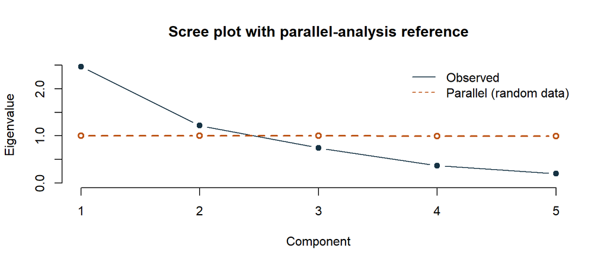

```r
plot(eig, type = "b", pch = 19, col = "#153243", bty = "n", xlab = "Component",
     ylab = "Eigenvalue", main = "Scree plot with parallel-analysis reference",
     ylim = c(0, max(eig)))
lines(dimensions$parallel$pc.sim[seq_along(eig)], type = "b", lty = 2, lwd = 2, col = "#bd5416")
legend("topright", c("Observed", "Parallel (random data)"), lty = c(1, 2),
       col = c("#153243", "#bd5416"), bty = "n")
```

### 7.2 Compare one-, two-, and three-dimension solutions

```r
X <- ind[cc, sel]
show_loadings <- function(k) {
  m <- psych::principal(X, nfactors = k, rotate = if (k > 1) "oblimin" else "none")
  L <- unclass(m$loadings); colnames(L) <- paste0("k", k, "_C", seq_len(k))
  L
}
kable(do.call(cbind, lapply(1:3, show_loadings)), digits = 2)
```

|  | k1_C1 | k2_C1 | k2_C2 | k3_C1 | k3_C2 | k3_C3 |
| --- | --- | --- | --- | --- | --- | --- |
| days_cash_ops | 0.71 | 0.68 | 0.20 | 0.05 | 0.95 | 0.12 |
| liquid_assets_months | 0.73 | 0.88 | 0.01 | -0.03 | 0.73 | -0.35 |
| debt_assets | -0.53 | -0.77 | 0.13 | -0.03 | 0.00 | 0.97 |
| surplus_margin | 0.79 | 0.07 | 0.92 | 0.90 | 0.13 | 0.03 |
| return_assets | 0.72 | -0.05 | 0.95 | 0.97 | -0.09 | -0.04 |

```r
efa <- psych::fa(X, nfactors = 2, rotate = "oblimin", fm = "minres")
kable(unclass(efa$loadings), digits = 2, caption = "EFA (minres, oblimin), 2 factors")
```

EFA (minres, oblimin), 2 factors

|  | MR1 | MR2 |
| --- | --- | --- |
| days_cash_ops | 0.20 | 0.50 |
| liquid_assets_months | -0.02 | 1.01 |
| debt_assets | -0.04 | -0.44 |
| surplus_margin | 0.99 | 0.02 |
| return_assets | 0.80 | -0.03 |

```r
cat("Factor correlation:", fmt(efa$Phi[1, 2], 2), "\n")
```

```
## Factor correlation: 0.33
```

> **Decision 8: Retain two dimensions.**

> *Why:*
> - **Parallel analysis** keeps 2 components: only those eigenvalues exceed what random data of the same size produce.
> - **Simple structure.** The two-component solution has no cross-loadings, and every indicator loads above 0.60 on exactly one component.
> - **The one-component solution** loads everything in the expected direction. That is evidence a general health factor exists and that a composite is meaningful. But it explains less than half the variance and hides the distinction between stocks and flows (Section 8).
> - **The three-component solution** just splits `debt_assets` off as a singleton. A one-indicator “dimension” is not a latent construct, and its eigenvalue sits below the parallel-analysis threshold.
> - **EFA agrees.** Common-factor analysis, which models only shared variance, recovers the same two groups.

### 7.3 Stability

A dimension worth naming should reappear in independent halves of the data and in organizations of very different size. We use Tucker’s congruence coefficient between loading matrices. Values of 0.95 or higher mean the factors are effectively equal; 0.85–0.94 means fair similarity.

```r
loadings_for <- function(rows) {
  unclass(psych::principal(ind[rows, sel], nfactors = 2, rotate = "oblimin")$loadings)
}
match_congruence <- function(A, B) {
  C <- psych::factor.congruence(A, B)
  # align components by best absolute match
  diag(C[, apply(abs(C), 1, which.max), drop = FALSE])
}
half <- sample(cc, length(cc) / 2)
rev_total <- num(f$F9_08_REV_TOT_TOT)
groups <- list(
  `Random half A vs. half B`   = list(half, setdiff(cc, half)),
  `Revenue < $500k vs. >= $5M` = list(cc[rev_total[cc] < 5e5], cc[rev_total[cc] >= 5e6]),
  `$500k-$5M vs. full sample`  = list(cc[rev_total[cc] >= 5e5 & rev_total[cc] < 5e6], cc)
)
stab <- do.call(rbind, lapply(names(groups), function(g) {
  cg <- match_congruence(loadings_for(groups[[g]][[1]]), loadings_for(groups[[g]][[2]]))
  data.frame(comparison = g, n_first = length(groups[[g]][[1]]),
             n_second = length(groups[[g]][[2]]),
             congruence_C1 = cg[1], congruence_C2 = cg[2])
}))
kable(stab, digits = 3, row.names = FALSE,
      format.args = list(big.mark = ","))
```

| comparison | n_first | n_second | congruence_C1 | congruence_C2 |
| --- | --- | --- | --- | --- |
| Random half A vs. half B | 157,213 | 157,214 | 1.00 | 1.00 |
| Revenue < $500k vs. >= $5M | 158,727 | 40,866 | 0.94 | 0.97 |
| $500k-$5M vs. full sample | 114,834 | 314,427 | 1.00 | 1.00 |

```r
# Label components by content so small/large columns line up.
label_cols <- function(L) {
  perf <- which.max(abs(L["surplus_margin", ]))
  L <- L[, c(setdiff(1:2, perf), perf)]
  colnames(L) <- c("reserves", "performance")
  L
}
L_small <- label_cols(loadings_for(groups[[2]][[1]]))
L_large <- label_cols(loadings_for(groups[[2]][[2]]))
kable(cbind(`small: reserves` = L_small[, 1], `small: performance` = L_small[, 2],
            `large: reserves` = L_large[, 1], `large: performance` = L_large[, 2]),
      digits = 2,
      caption = "Two-component loadings, small (<$500k) and large (>=$5M) organizations")
```

Two-component loadings, small (<$500k) and large (>=$5M) organizations

|  | small: reserves | small: performance | large: reserves | large: performance |
| --- | --- | --- | --- | --- |
| days_cash_ops | 0.71 | 0.16 | 0.26 | 0.50 |
| liquid_assets_months | 0.89 | -0.01 | 0.87 | 0.04 |
| debt_assets | -0.72 | 0.11 | -0.86 | 0.04 |
| surplus_margin | 0.07 | 0.91 | 0.06 | 0.92 |
| return_assets | -0.06 | 0.95 | -0.08 | 0.95 |

> **Stability finding.** The structure reproduces essentially perfectly across random halves. It also holds across a ten-fold difference in organization size (congruence ≥ 0.94). One indicator shifts. Among large organizations, `days_cash_ops` loads more on the performance component (0.50) than on reserves (0.26). Among small organizations it is a clean reserve indicator (0.71). The likely reason: for large operating nonprofits, cash and receivables relative to spending track this year’s operating results more closely than accumulated equity does. Months of liquid net assets and debt-to-assets anchor the balance-sheet dimension at every size. `days_cash_ops` is kept on that dimension because it belongs there conceptually and in the pooled solution. Users analyzing only large organizations should read the reserve score with this in mind.

## 8. Naming and interpreting the dimensions

```r
kable(dimensions$assignments[, c("variable", "primary_dimension", "primary_loading",
                                 "secondary_abs_loading", "status")],
      digits = 2, row.names = FALSE)
```

| variable | primary_dimension | primary_loading | secondary_abs_loading | status |
| --- | --- | --- | --- | --- |
| days_cash_ops | Dimension1 | 0.68 | 0.20 | assigned |
| liquid_assets_months | Dimension1 | 0.88 | 0.01 | assigned |
| debt_assets | Dimension1 | -0.77 | 0.13 | assigned |
| surplus_margin | Dimension2 | 0.92 | 0.07 | assigned |
| return_assets | Dimension2 | 0.95 | 0.05 | assigned |

```r
members <- split(dimensions$assignments$variable, dimensions$assignments$primary_dimension)
label_for <- function(m) {
  if ("liquid_assets_months" %in% m) "reserves_solvency"
  else if ("surplus_margin" %in% m) "operating_performance"
  else NA_character_
}
dimension_names <- vapply(members, label_for, character(1))
stopifnot(!anyNA(dimension_names), !anyDuplicated(dimension_names))
dimension_names
```

```
##              Dimension1              Dimension2
##     "reserves_solvency" "operating_performance"
```

The labels come from what the grouped indicators have in common: their accounting source, their time horizon, and the financial question they answer. Dimensions are matched to labels by indicator membership, not by component number, so the labels stay correct if the component order changes on re-estimation.

#### Dimension A: Reserves and Solvency (`reserves_solvency`)

| Indicator | Sign | What it measures |
| --- | --- | --- |
| `liquid_assets_months` | + | Liquid unrestricted net assets (net of property, plus mortgage debt) in months of spending |
| `days_cash_ops` | + | Cash, savings, and receivables in days of cash operating expenses |
| `debt_assets` | − | Share of assets financed by liabilities |

**Why this label.**

- *Same source and horizon.* All three are **balance-sheet stocks** measured at year end. None depends on this year’s revenue or surplus.
- *Same question.* How much cushion does the organization have, and how much of it is already claimed? The two reserve measures express the cushion in units of spending (months or days it could keep operating). Debt-to-assets loads negatively because liabilities are claims against that cushion: a leveraged organization’s apparent assets are less available to absorb a shock.
- *Why “solvency” is in the name.* Parallel analysis did not support separating leverage from liquidity (the three-component solution only splits off a singleton). Keeping `debt_assets` in the label makes clear the dimension covers both *having* reserves and *not owing* them away.

**Interpretation.** High scores mean financial resilience: enough liquid, unencumbered equity to ride out a revenue disruption, delayed reimbursement, or unexpected cost. Low scores mean thin or negative liquid reserves and heavy reliance on borrowed resources. Such organizations are vulnerable even in a year with a surplus. This dimension changes slowly; it is the accumulated result of past years.

#### Dimension B: Operating Performance (`operating_performance`)

| Indicator | Sign | What it measures |
| --- | --- | --- |
| `surplus_margin` | + | Revenue less expenses, as a share of revenue |
| `return_assets` | + | Revenue less expenses, as a share of total assets |

**Why this label.**

- *Same source and horizon.* Both are **income-statement flows** for the current year. They share a numerator (the annual surplus or deficit) and differ only in denominator (revenue vs. assets). Their loadings reflect that shared numerator.
- *Why not “profitability.”* That term implies profit maximization, which is not a nonprofit objective. “Operating performance” describes whether the year’s activities covered their full cost, including depreciation, which is the quantity lenders, funders, and boards monitor.

**Interpretation.** High scores mean the organization covered its costs this year with room to spare, which is the source of future reserves. Low scores mean an operating deficit. A single deficit year is not distress, and deficits can be deliberate spend-downs of prior surpluses. Persistent low scores erode Dimension A.

#### How the two dimensions relate

```r
cat("Correlation between the two components (oblimin, full sample):",
    fmt(psych::principal(X, nfactors = 2, rotate = "oblimin")$Phi[1, 2], 2), "\n")
```

```
## Correlation between the two components (oblimin, full sample): 0.31
```

The dimensions are positively but modestly correlated. That matches the stock–flow logic: surpluses build reserves over time, but in any one year many organizations have strong balance sheets and a deficit, or the reverse. This modest correlation is why the index reports **both** dimension scores next to the composite. Two organizations with the same composite can have very different profiles: a well-reserved organization spending down savings, or a thinly capitalized one running surpluses.

## 9. Stage 4–7: Fit, score, weight, index

### 9.1 Fit the measurement model

```r
directions <- c(liquid_assets_months = "higher", days_cash_ops = "higher",
                debt_assets = "lower", surplus_margin = "higher",
                return_assets = "higher", prog_exp = "higher", self_suff = "higher")
fit <- fiscal_health_fit(ind, dimensions = dimensions,
                         dimension_names = dimension_names,
                         scoring = "standardized_mean",
                         indicator_direction = directions,
                         missing = "median", strict_direction = TRUE)
fit
```

```
## Fitted fiscal-health measurement model
##   Dimensions: 2
##   Standalone indicators: 2
##   Reference observations: 314548
##   Missing-value rule: median
```

> **Decision 9: Score each dimension as the standardized mean of its oriented indicators.**

> *Why:* With two or three indicators per dimension, a simple average is transparent, reproducible, and needs no estimated weights. The check below shows it is practically indistinguishable from first-principal-component scoring. Orientation is set explicitly (`strict_direction = TRUE`) rather than inferred, so the direction of every indicator is part of the audit record.

```r
fit_pca <- fiscal_health_fit(ind, dimensions = dimensions, dimension_names = dimension_names,
                             scoring = "pca", indicator_direction = directions,
                             missing = "median")
s_mean <- fiscal_health_score(ind, fit, append = FALSE, include_standalone = FALSE)
s_pca  <- fiscal_health_score(ind, fit_pca, append = FALSE, include_standalone = FALSE)
kable(data.frame(dimension = dimension_names,
                 r_mean_vs_pca = sapply(paste0("fh_", dimension_names),
                                        function(v) cor(s_mean[[v]], s_pca[[v]], use = "pair")),
                 cronbach_alpha = sapply(dimension_names, function(dn) {
                   spec <- fit$dimensions[[dn]]
                   z <- sweep(as.matrix(ind[spec$indicators]), 2, spec$indicator_multiplier, "*")
                   psych::alpha(z, check.keys = FALSE, warnings = FALSE)$total$raw_alpha
                 })), digits = 3, row.names = FALSE)
```

| dimension | r_mean_vs_pca | cronbach_alpha |
| --- | --- | --- |
| reserves_solvency | 0.999 | 0.696 |
| operating_performance | 1.000 | 0.878 |

Internal consistency is acceptable for Reserves & Solvency and high for Operating Performance. Read both with care. The performance alpha is partly mechanical, because its two indicators share a numerator (annual surplus). The reserve alpha is held down by combining assets (reserves) with liabilities (leverage). Accounting ratios are not survey items written to measure one trait, so the scores are best read as **formative summaries** of a coherent block of ratios, not as reflective latent traits.

### 9.2 Score, weight, and build the composite

```r
scored  <- fiscal_health_score(ind, fit)
weights <- fiscal_weights(fit, include_standalone = FALSE, min_coverage = 0.5)
weights
```

```
## Fiscal-health weights
##   Method: equal
##   Measures: 2
##   Missing-score rule: reweight
##                measure measure_type original_weight weight
##      reserves_solvency    dimension               1    0.5
##  operating_performance    dimension               1    0.5
```

```r
indexed <- fiscal_health_index(scored, weights)
indexed$fiscal_health_pctile <- dplyr::ntile(indexed$fiscal_health, 100)
```

> **Decision 10: Weight the composite 50/50 across the two dimensions, and keep the standalone indicators (`prog_exp`, `self_suff`) out of it.**

> *Why equal weights:* No external outcome in a single cross-section can calibrate weights (for example, later closure or insolvency). The two dimensions carry similar variance, and equal weights are the transparent default that is easiest to defend. `fiscal_weights()` accepts custom weights once panel outcomes are available to calibrate against.

> *Why exclude the standalones:* With equal weighting, each standalone would get as much weight as a whole dimension.
> - **`prog_exp`** has communality near zero: it carries almost no information about reserves or results. Its “higher is better” reading is contested, since chronic underinvestment in administration is a documented risk factor (the “nonprofit starvation cycle”).
> - **`self_suff`** (program revenue ÷ expenses) describes the revenue model. A donor-funded organization with low self-sufficiency is not less healthy.

> Both are still scored (`fh_prog_exp`, `fh_self_suff`) and returned for descriptive use.

## 10. Results

### 10.1 Distribution of scores

```r
score_cols <- c(paste0("fh_", dimension_names), "fiscal_health")
kable(t(sapply(indexed[score_cols], function(v)
  c(n = sum(!is.na(v)), mean = mean(v, na.rm = TRUE), sd = sd(v, na.rm = TRUE),
    quantile(v, c(.05, .25, .5, .75, .95), na.rm = TRUE)))), digits = 2)
```

|  | n | mean | sd | 5% | 25% | 50% | 75% | 95% |
| --- | --- | --- | --- | --- | --- | --- | --- | --- |
| fh_reserves_solvency | 314548 | 0 | 1.00 | -1.70 | -0.66 | 0.02 | 0.67 | 1.62 |
| fh_operating_performance | 314548 | 0 | 1.00 | -1.61 | -0.81 | 0.09 | 0.75 | 1.54 |
| fiscal_health | 314548 | 0 | 0.82 | -1.32 | -0.56 | 0.00 | 0.56 | 1.33 |

```r
kable(round(cor(indexed[score_cols], use = "pair"), 2))
```

|  | fh_reserves_solvency | fh_operating_performance | fiscal_health |
| --- | --- | --- | --- |
| fh_reserves_solvency | 1.00 | 0.34 | 0.82 |
| fh_operating_performance | 0.34 | 1.00 | 0.82 |
| fiscal_health | 0.82 | 0.82 | 1.00 |

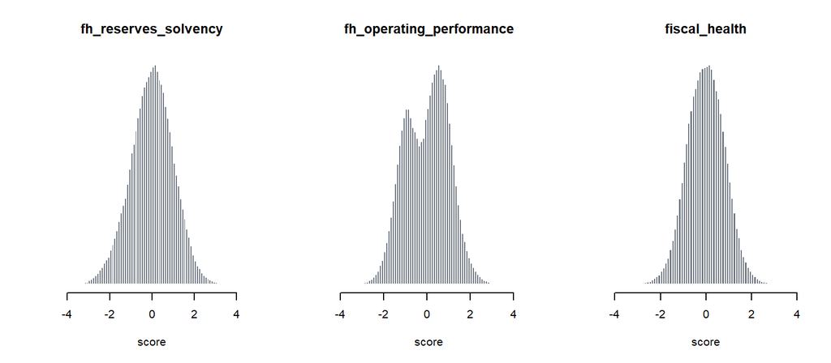

```r
par(mfrow = c(1, 3))
for (v in score_cols) hist(indexed[[v]], breaks = 60, main = v, xlab = "score", col = "#6d7681", border = "white", yaxt = "n", ylab = "")
```

### 10.2 Face validity: raw financial conditions by index quintile

If the index measures fiscal health, quintiles should line up with raw, untransformed conditions that analysts recognize as distress signals. The check is partly circular, since these conditions feed the index. Still, it confirms that orientation and scoring behave as intended on the raw scale, including at the extremes that rank-normal scoring compresses.

```r
validity <- data.frame(
  quintile        = dplyr::ntile(indexed$fiscal_health, 5),
  deficit         = f$surplus_margin < 0,
  neg_net_assets  = zero(f$F9_10_NAFB_TOT_EOY) < 0,
  neg_liquid      = f$liquid_assets_months < 0,
  under_1mo_liquid = f$liquid_assets_months < 1,
  liquid_months   = f$liquid_assets_months,
  surplus_margin  = f$surplus_margin,
  revenue         = rev_total
)
kable(validity |>
  group_by(quintile) |>
  summarise(n = n(),
            `deficit year` = pct(mean(deficit, na.rm = TRUE)),
            `negative net assets` = pct(mean(neg_net_assets, na.rm = TRUE)),
            `negative liquid reserves` = pct(mean(neg_liquid, na.rm = TRUE)),
            `< 1 month liquid reserves` = pct(mean(under_1mo_liquid, na.rm = TRUE)),
            `median liquid months` = fmt(median(liquid_months, na.rm = TRUE), 1),
            `median surplus margin` = pct(median(surplus_margin, na.rm = TRUE)),
            `median revenue ($)` = format(round(median(revenue, na.rm = TRUE)), big.mark = ",")),
  align = "r")
```

| quintile | n | deficit year | negative net assets | negative liquid reserves | < 1 month liquid reserves | median liquid months | median surplus margin | median revenue ($) |
| --- | --- | --- | --- | --- | --- | --- | --- | --- |
| 1 | 62910 | 90.9% | 20.2% | 33.5% | 53.9% | 0.8 | -13.5% | 583,252 |
| 2 | 62910 | 64.0% | 3.2% | 8.6% | 16.5% | 4.7 | -3.2% | 681,574 |
| 3 | 62910 | 32.3% | 0.9% | 3.7% | 8.6% | 7.9 | 3.4% | 591,764 |
| 4 | 62909 | 9.0% | 0.2% | 1.5% | 3.7% | 12.2 | 12.8% | 466,993 |
| 5 | 62909 | 0.5% | 0.0% | 0.4% | 1.2% | 34.4 | 39.2% | 302,112 |

Every distress signal falls steadily from the bottom quintile to the top. Two patterns deserve attention:

- **The top quintile is not the largest organizations.** Median revenue is lowest in the top quintile. Small organizations with no debt and accumulated reserves score well, while large operating nonprofits (hospitals, human-service providers) carry more liabilities and run thinner margins by design. The index measures financial *condition relative to scale*, not institutional strength.
- **The index treats more as better without limit.** The top quintile’s median surplus margin is very high. Some of these organizations are raising capital or collecting multi-year grants in one year, and some hold reserves far beyond operating need. The index does not penalize accumulation.

### 10.3 Profiles: agreement and disagreement between dimensions

```r
hi <- function(v) v >= median(v, na.rm = TRUE)
prof <- table(
  `Reserves & Solvency`   = ifelse(hi(indexed$fh_reserves_solvency), "above median", "below median"),
  `Operating Performance` = ifelse(hi(indexed$fh_operating_performance), "above median", "below median"))
kable(as.data.frame.matrix(round(100 * prop.table(prof), 1)),
      caption = "Percent of organizations. Rows: Reserves & Solvency; columns: Operating Performance")
```

Percent of organizations. Rows: Reserves & Solvency; columns: Operating Performance

|  | above median | below median |
| --- | --- | --- |
| above median | 31.2 | 18.8 |
| below median | 18.8 | 31.2 |

The off-diagonal cells are where the two-dimension design matters most. Those organizations are either spending down healthy reserves or earning surpluses on thin balance sheets, and a single composite would put them in the same place.

### 10.4 Output data

```r
out <- cbind(
  d[, intersect(c("EIN2", "ORG_EIN", "ORG_NAME_L1", "TAX_YEAR", "RETURN_TYPE"), names(d))],
  f[, pool],
  indexed[, c(score_cols, "fiscal_health_pctile", "fh_prog_exp", "fh_self_suff")]
)
saveRDS(list(data = out, fit = fit, weights = weights, triage = triage,
             dimensions = dimensions, reference_indicators = ind),
        file.path(params$data_dir, "fiscal-health-index-2023.rds"))
head(out[, c("ORG_NAME_L1", score_cols, "fiscal_health_pctile")])
```

|  | ORG_NAME_L1 | fh_reserves_solvency | fh_operating_performance | fiscal_health | fiscal_health_pctile |
| --- | --- | --- | --- | --- | --- |
| 4 | AMERICAN LEGION AUXILIARY DEPARTMENT OF MAINE | 1.0261119 | 0.2434161 | 0.6347640 | 78 |
| 5 | AMERICAN LEGION POST 5 BOURQUE-LANIGAN | -0.0421292 | -0.8777189 | -0.4599240 | 30 |
| 6 | AMERICAN LEGION - MAINE DEPARTMENT | -0.4615086 | -0.4872813 | -0.4743949 | 29 |
| 7 | ANCIENT FREE AND ACCEPTED MASONS OF | 1.0281687 | 0.4020263 | 0.7150975 | 81 |
| 8 | AUGUSTA COUNTRY CLUB | -2.0698801 | 0.2055231 | -0.9321785 | 13 |
| 9 | KENNEBEC VALLEY CHAMBER OF COMMERCE | 0.1024645 | -0.1577293 | -0.0276324 | 49 |

## Summary of decisions

| # | Stage | Decision | Principal reason |
| --- | --- | --- | --- |
| 1 | Sample | Full 990 filers with positive revenue, expenses, and assets | Most ratios need Part IX/X detail; 990-EZ rows would add structural zeros |
| 2 | Inputs | Total net assets stand in for unrestricted net assets when lines 27–28 are blank | ~1 in 4 filers do not follow SFAS 117; their reserves would read as zero |
| 3 | Inputs | Correct cash/assets numerator; drop overhead | Package functions diverge from their documented formulas |
| 4 | Pool | 12 of 48 metrics enter the model | Only directional, scale-free, defined, monotone, non-identical ratios |
| 5 | Transform | Rank-normal scores instead of `_z` | `_z` attenuates the raw correlations the model depends on |
| 6 | Triage | `cash_assets`, `assets_rev` to review | KMO < 0.50; direction depends on business model; they create a spurious third component |
| 7 | Triage | `surplus_margin` over `profit_predepr` | KMO tie; surplus margin is the standard bottom-line measure |
| 8 | Dimensions | Two dimensions | Parallel analysis, simple structure, EFA agreement, stable across halves and size |
| 9 | Scoring | Standardized mean, explicit directions | Transparent; r ≈ 1 with PCA scoring |
| 10 | Composite | Equal weights; standalones excluded | No outcome to calibrate against; standalones are not condition measures |

**Retained dimensions.**

- **Reserves & Solvency** (balance-sheet stocks): liquid reserves and cash runway, net of leverage. It measures *resilience*, the capacity to absorb shocks.
- **Operating Performance** (income-statement flows): surplus relative to revenue and assets. It measures whether *current operations are sustainable*.

## Limitations and next steps

- **One cross-section.** Stability across tax years, and predictive validity (does a low score precede closure, filing lapses, or deficits?), need the multi-year panel. Scoring later years on the 2023 scale needs a reference-quantile version of the rank-normal transform.
- **Monotone scoring.** Every indicator is treated as better-when-higher (or lower), with no ceiling. Adding an “excess reserves” or target-range rule, for example a penalty above a benchmark number of months of reserves, would be a substantive policy choice, and it is left to users.
- **Coverage.** Organizations filing 990-EZ or 990-N are out of scope. A 990-EZ-compatible variant could use the Part I and Part II fields shared by both forms.
- **Industry context.** Reserve norms differ by subsector: hospitals and universities differ from arts groups or food banks. The index is comparable *across* the sector as defined here. NTEE-relative percentiles (via the BMF merge) would add within-field comparisons.
- **Package fixes to follow up:**
  - `get_overhead_ratio()` numerator
  - `get_cash_assets_ratio()` numerator
  - the SFAS 117 net-asset gap in reserve metrics
  - the `fundr_eff` registry direction
  - the `days_cash_inv` / current-ratio use of `F9_10_ASSET_INV_SALE_EOY` (inventories)
  - the `_z` normalization, which distorts correlations